# HubertBanieckiPd5

Hubert Baniecki

28 04 2019

# 1 Dane

W tej pracy domowej przetestuję implementacje modelu drzew `rpart` w R.  
Do testów wykorzystam dane `titanic` z pakietu `DALEX`.

```r
head(titanic)
```

|  | gender | age | class | embarked | country | fare | sibsp | parch | survived |
| --- | --- | --- | --- | --- | --- | --- | --- | --- | --- |
| 1 | male | 42 | 3rd | Southampton | United States | 7.11 | 0 | 0 | no |
| 2 | male | 13 | 3rd | Southampton | United States | 20.05 | 0 | 2 | no |
| 3 | male | 16 | 3rd | Southampton | United States | 20.05 | 1 | 1 | no |
| 4 | female | 39 | 3rd | Southampton | England | 20.05 | 1 | 1 | yes |
| 5 | female | 16 | 3rd | Southampton | Norway | 7.13 | 0 | 0 | yes |
| 6 | male | 25 | 3rd | Southampton | United States | 7.13 | 0 | 0 | yes |

```r
dim(titanic)
```

```
## [1] 2207    9
```

```r
df <- titanic
df$survived <- as.factor(ifelse(df$survived == "yes", 1, 0))
df$gender <- as.numeric(df$gender)
df$class <- as.numeric(df$class)
df$embarked <- as.numeric(df$embarked)
df$country <- as.numeric(df$country)

set.seed(1234)
ind <- sample(2207, round(0.7*2207))
train <- df[ind,]
test <- df[-ind,]
```

Podzieliłem dane na zbiór treningowy i testowy (70%/30%). Będziemy przewidywać kolumnę binarną `survived`.

# 2 Model drzew

```r
library(rpart)
```

## 2.1 Default

Najpierw sprawdźmy jak poradzi sobie model z parametrami domyślnymi, zaproponowanymi przez twórców pakietu.

```r
fit1 <- rpart(survived ~. , method = "class", data = train)

pred1 <- predict(fit1, newdata = test, type = "prob")
auc1 <- AUC(pred1[,2], test$survived)
auc1
```

```
## [1] 0.7127866
```

## 2.2 Proponowane hiperparametry

Teraz przetestujmy model na parametrach zaproponowanych w pracy naukowej.

```r
parameters <- rpart.control(minsplit = 24, minbucket = 12, cp = 0, maxdepth = 21)

list(cp = 0, maxdepth = 21, minbucket = 12, minsplit = 24)
```

```
## $cp
## [1] 0
##
## $maxdepth
## [1] 21
##
## $minbucket
## [1] 12
##
## $minsplit
## [1] 24
```

```r
fit2 <- rpart(survived ~. , method = "class", data = train, control = parameters)

pred2 <- predict(fit2, newdata = test, type = "prob")
auc2 <- AUC(pred2[,2], test$survived)
auc2
```

```
## [1] 0.7877996
```

Jak widać wynik `AUC` znacznie się poprawił.

## 2.3 Random search

W celu znalezienia optymalnych parametrów użyję przeszukiwania losowego.  
Zobaczmy, czy po 600 iteracjach dostaniemy lepszy wynik.

```r
clearn <- makeLearner("classif.rpart", predict.type = "prob")
task <- makeClassifTask(id = "task", data = train, target = "survived")

cv <- makeResampleDesc("CV", iters = 10)

ps <- makeParamSet(
  makeNumericParam("cp", lower = 0.00000001, upper = 0.2),
  makeIntegerParam("maxdepth", lower = 3, upper = 30),
  makeIntegerParam("minbucket", lower = 3, upper = 50),
  makeIntegerParam("minsplit", lower = 3, upper = 50)
)
ctrlRandom <- makeTuneControlRandom(maxit = 600L)

res <- tuneParams(clearn, task = task, measures = auc,
                  resampling = cv, par.set = ps, control = ctrlRandom)

res$x
```

```
## $cp
## [1] 0.003773905
##
## $maxdepth
## [1] 23
##
## $minbucket
## [1] 8
##
## $minsplit
## [1] 44
```

```r
fit3 <-  rpart(survived ~. , method = "class", data = train, control = res$x)

pred3 <- predict(fit3, newdata = test, type = "prob")
auc3 <- AUC(pred3[,2], test$survived)
auc3
```

```
## [1] 0.7885601
```

```r
predx <- predict(fit3, newdata = train, type = "prob")
aucx <- AUC(predx[,2], train$survived)
aucx
```

```
## [1] 0.809125
```

# 3 Najlepszy model

Po dużej liczbie iteracji znaleźliśmy lepsze parametry, ale bardzo niewiele zyskaliśmy.

## 3.1 Rysunek drzewa

Poniżej rysunek drzewa najlepszego modelu.  
Wydaje się, że zmienne `age`, `gender` i `class` miały największe znaczenie przy podziale.

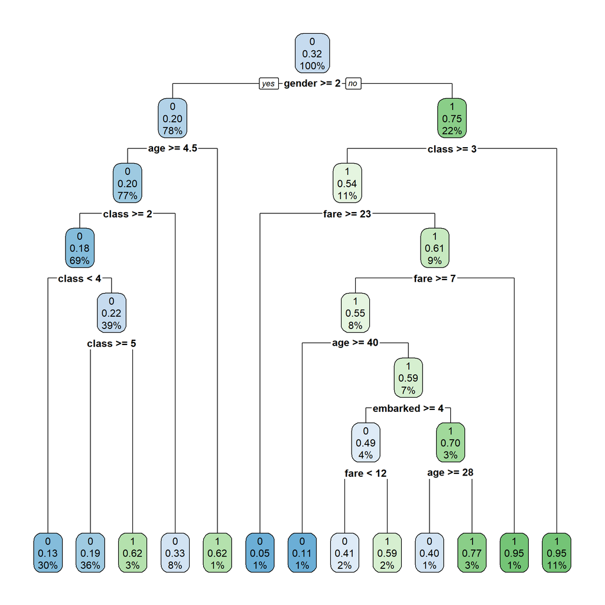

```r
rpart.plot(fit3, uniform = TRUE )
```

## 3.2 Reguły decyzyjne

Poniżej reguły decyzyjne zilustrowane na wykresie wyżej.

```r
print(fit3)
```

```
## n= 1545
##
## node), split, n, loss, yval, (yprob)
##       * denotes terminal node
##
##   1) root 1545 502 0 (0.67508091 0.32491909)
##     2) gender>=1.5 1205 246 0 (0.79585062 0.20414938)
##       4) age>=4.5 1184 233 0 (0.80320946 0.19679054)
##         8) class>=1.5 1062 193 0 (0.81826742 0.18173258)
##          16) class< 3.5 462  58 0 (0.87445887 0.12554113) *
##          17) class>=3.5 600 135 0 (0.77500000 0.22500000)
##            34) class>=4.5 552 105 0 (0.80978261 0.19021739) *
##            35) class< 4.5 48  18 1 (0.37500000 0.62500000) *
##         9) class< 1.5 122  40 0 (0.67213115 0.32786885) *
##       5) age< 4.5 21   8 1 (0.38095238 0.61904762) *
##     3) gender< 1.5 340  84 1 (0.24705882 0.75294118)
##       6) class>=2.5 164  75 1 (0.45731707 0.54268293)
##        12) fare>=23.07 20   1 0 (0.95000000 0.05000000) *
##        13) fare< 23.07 144  56 1 (0.38888889 0.61111111)
##          26) fare>=7.04575 123  55 1 (0.44715447 0.55284553)
##            52) age>=39.5 9   1 0 (0.88888889 0.11111111) *
##            53) age< 39.5 114  47 1 (0.41228070 0.58771930)
##             106) embarked>=3.5 61  30 0 (0.50819672 0.49180328)
##               212) fare< 12.04085 34  14 0 (0.58823529 0.41176471) *
##               213) fare>=12.04085 27  11 1 (0.40740741 0.59259259) *
##             107) embarked< 3.5 53  16 1 (0.30188679 0.69811321)
##               214) age>=27.5 10   4 0 (0.60000000 0.40000000) *
##               215) age< 27.5 43  10 1 (0.23255814 0.76744186) *
##          27) fare< 7.04575 21   1 1 (0.04761905 0.95238095) *
##       7) class< 2.5 176   9 1 (0.05113636 0.94886364) *
```

# 4 Kryterium podziału drzew

Na koniec zobaczmy jak kryterium podziału wpłynie na wynik modelu.  
Użyję parametrów, które dały poprzednio najlepsze `AUC`.

## 4.1 Information Gain

```r
fit4 <- rpart(survived ~. , method="class", data = train, control = res$x, parms = list(split = 'information'))

pred4 <- predict(fit4, newdata = test, type = "prob")
auc4 <- AUC(pred4[,2], test$survived)
auc4
```

```
## [1] 0.7932602
```

## 4.2 Gini

```r
fit5 <- rpart(survived ~. , method="class", data = train, control = res$x, parms = list(split = 'gini'))

pred5 <- predict(fit5, newdata = test, type = "prob")
auc5 <- AUC(pred5[,2], test$survived)
auc5
```

```
## [1] 0.7885601
```

Zmiana kryterium podziału na Information Gain wyniosła nasz model powyżej `79% AUC`.  
Warto dodać, że model ten działa bardzo szybko w porównaniu z bardziej skomplikowanymi.  
Łatwo go też wyjaśnić za pomocą reguł lub rysunku.